# Sesión 5 - Dickey Fuller Test

Universidad Nacional de Colombia - Facultad de Ciencias Económicas

Equipo de monitores - Econometría II

2023-09-18

# Carga y descarga de paquetes

Para el tratamiento de series temporales, estimación de modelos y comprobación de resultados requerimos de las funciones de algunos paquetes no nativos.

El proceso se realizará con el comando “pacman”, el cual carga los paquetes ya instalados y descarga (para posteriormente cargar) los no instalados.

```r
pacman :: p_load(
  forecast,   # Realiza predicción y autoplot
  lmtest,     # Significancia individual Coeficientes ARIMA
  tseries,    # Para estimar modelos de series de tiempo y pruebas de supuestos
  readxl,     # Para leer archivos de excel
  stargazer,  # Presentación de resultados y tablas más estéticos
  tidyverse,  # Conjunto de paquetes (incluye dplyr y ggplot2)
  dynlm,      # Paquete que me permite realizar MCOD
  urca        # Prueba de raíz unitaria
)
```

# 1. Simulación de Montecarlo

## 1.1 Descripción

La primera parte del script consistirá en realizar una serie de simulaciones de Monte Carlo, de tal forma que se pueda obtener la distribución empírica del estadístico de Dickey-Fuller.

La prueba se realiza evaluando la significancia de los estimadores de su regresión auxiliar, la cual puede tener distintos componentes según la serie a tratar:

1. Regresión con tendencia determínistica y deriva (*trend*)
2. Regresión con deriva (*drift*)
3. Regresión sencilla

## 1.2 Establecimiento de valores y funciones

Como en todo proceso de simulación (en tanto usamos la función *rnorm()* ), vamos preparar una semilla para reproducibilidad del código. Adicionalmente estableceramos un tamaño de muestra de cada serie de 100 observaciones y 10000 series para observar la distribución del estadístico.

```r
set.seed(1)
n = 100
N = 10000
```

Adicionalmente, establezcamos valores para la tendencia y la deriva.

```r
trend = 1:n # (tendencia deterministica lineal)
drift = 0.5 # (deriva)
```

La siguiente función genera un Data Frame donde se guardarán los coeficientes y los estadísticos de cada simulación de serie (10000 x 2) para finalmente observar su distribución.

```r
simulacion_DF = function(n, N, tipo_prueba, trend = 1:n, drift = 0.1){

  # Se crea un Data Frame vacio
    sim_df = data.frame(parametro_interes = double(), DF_statistic = double())

    # Tendencia y deriva
    if(tipo_prueba == "drift+trend"){

      # Se realiza la iteración de cada serie simulada
      for(i in 1:N){

        #1. Serie de Tiempo simulada
          yt = arima.sim(model= list(order = c(0,1,0)), n = n-1, innov = rnorm(n, mean = 0, sd =1)) + drift + trend

        # 2. Estadístico de la regresión auxiliar Dickey Fuller
          summa = summary(dynlm(diff(yt, 1) ~ L(yt, 1) + trend(yt)))

        # Extraemos el coeficiente y el t estadístico para agregarlos al DF
          sim_df[i,] = c(summa$coef[2,1], summa$coef[2,3])
      }
    # Establecemos lo mismo para la prueba únicamente con deriva y sencilla

    # Deriva
    }else if(tipo_prueba == "drift"){
    for(i in 1:N){
      yt = arima.sim(model= list(order = c(0,1,0)), n = n, innov = rnorm(n, mean = 0, sd =1)) + drift
      summa = summary(dynlm(diff(yt, 1) ~ L(yt, 1)))
      sim_df[i,] = c(summa$coef[2,1], summa$coef[2,3])
    }

    # Sencilla
  }else if(tipo_prueba == "none"){
    for(i in 1:N){
      yt = arima.sim(model= list(order = c(0,1,0)), n = n, innov = rnorm(n, mean = 0, sd =1))
      summa = summary(dynlm(diff(yt, 1) ~ L(yt, 1) - 1))
      sim_df[i,] = c(summa$coef[1,1], summa$coef[1,3])
    }
  }
  return(sim_df)
}
```

Finalmente establecemos una función para generar los histogramas con el Data Frame creado.

```r
# Histograma para el coeficiente
histogram_rho = function(df, titulo, x_lab, color_llenado, num_bins = 30){
  histog = df %>%
    ggplot(aes(x = parametro_interes)) +
    geom_histogram(color = "black", fill = color_llenado, bins = num_bins) +
    theme_light() +
    ggtitle(titulo) +
    ylab("Frencuencia") +
    xlab(x_lab)
  return(histog)
}

# Histograma para el estadístico de DF
histogram_DF = function(df, titulo, x_lab, color_llenado, num_bins = 30){
  histog = df %>%
    ggplot(aes(x = DF_statistic)) +
    geom_histogram(color = "black", fill = color_llenado, bins = num_bins, aes(y = ..density..)) +
    geom_density() +
    theme_light() +
    ggtitle(titulo) +
    ylab("Densidad") +
    xlab(x_lab)
  return(histog)
}
```

Tras establecer dichas funciones y parámetros, estamos listos para realizar las simulaciones de interés.

## 1.2 Simulación con tendencia y deriva

Recordemos que el test con estas especificaciones modela una tendencia determinística lineal y un intercepto (deriva).

Procedemos con las simulaciones almacenadas en el Data Frame.

```r
df_trend_drift = simulacion_DF(n = n, N = N, tipo_prueba = "drift+trend", trend = trend, drift = drift)
```

Los histogramas son un gráfico excelente para visualizar la distribución de variables aleatorias, de forma que en éste se pueden apreciar todos los momentos estadísticos.

En primer lugar graficamos la distribución del parámetro de interés

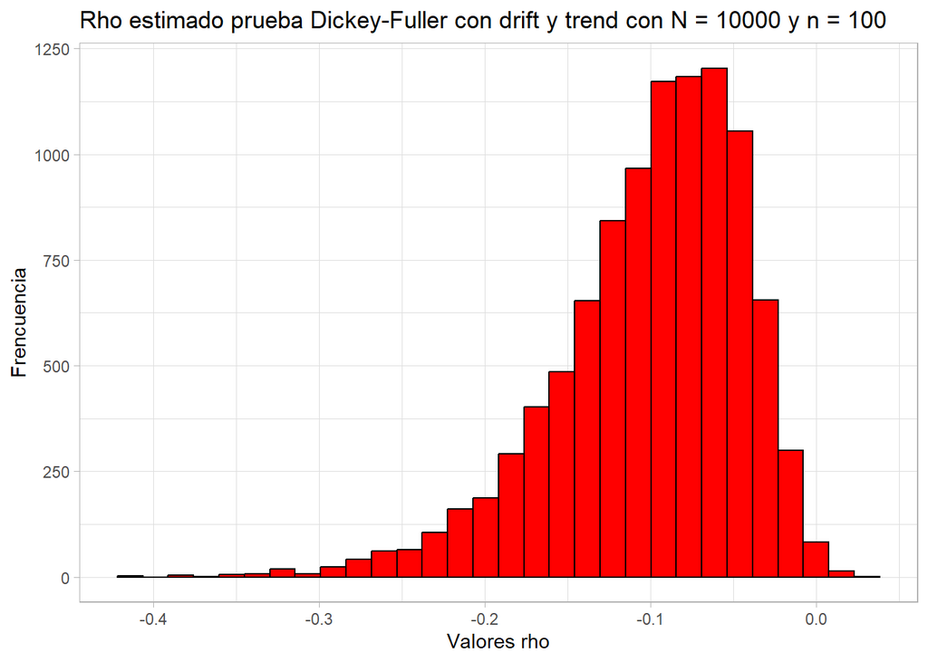

```r
histogram_rho_trend_drift=histogram_rho(df_trend_drift,"Rho estimado prueba Dickey-Fuller con drift y trend con N = 10000 y n = 100","Valores rho", "red1");histogram_rho_trend_drift
```

Es posible evidenciar una asimetría negativa y un rango que comprende valores en su mayoría menores a cero, esto dada la naturaleza de la prueba.

Veamos la distribución para el estadístico t.

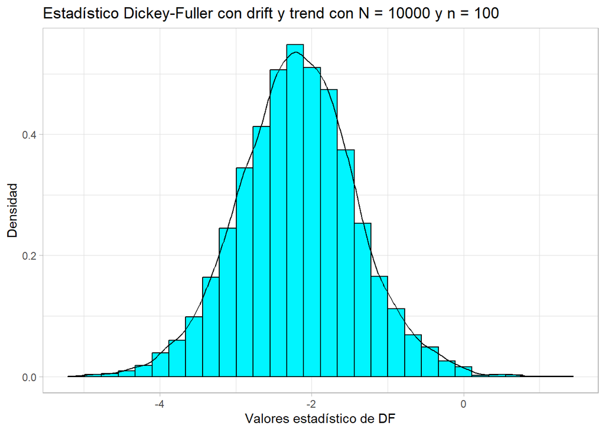

```r
hist_DF_trend_drift = histogram_DF(df_trend_drift,"Estadístico Dickey-Fuller con drift y trend con N = 10000 y n = 100","Valores estadístico de DF","turquoise1");hist_DF_trend_drift
```

Es posible evidenciar una distribución leptocúrtica sin colas muy pesadas, además de una simetría casi idéntica a la de la distribución normal. Nuevamente, el estadístico comprende un dominio negativo en tanto la varianza (y por ende la desviación estándar) tiene un rango positivo.

Observemos el valor crítico para niveles de significancia de 10%, 5% y 1%.

```r
critical_trend_drift = round(quantile(df_trend_drift$DF_statistic, c(0.1, 0.05, 0.01)), 2); critical_trend_drift
```

```
##   10%    5%    1%
## -3.16 -3.46 -4.03
```

Estos valores se contrastan con el valor calculado, para proceder a hacer una prueba de hipótesis de cola izquierda.

## 1.3 Simulación con deriva

La siguiente variación de la prueba Dickey Fuller sugiere un término constante, pero sin término determinístico de la tendencia.

Procedemos a generar la simulación.

```r
df_drift = simulacion_DF(n = n, N = N, tipo_prueba = "drift", trend = trend, drift = drift)
```

Graficamos la distribución del parámetro de interés.

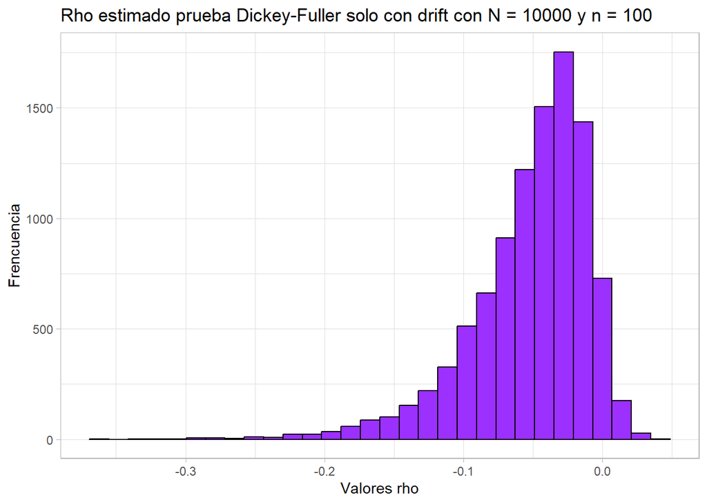

```r
histogram_rho_drift = histogram_rho(df_drift,"Rho estimado prueba Dickey-Fuller solo con drift con N = 10000 y n = 100","Valores rho", "purple1");histogram_rho_drift
```

Como podemos ver, el Parámetro Rho conserva su comportamiento de asimetría negativa con leptocurtosis.

Analicemos el estadístico t con el que se comprueba su significancia.

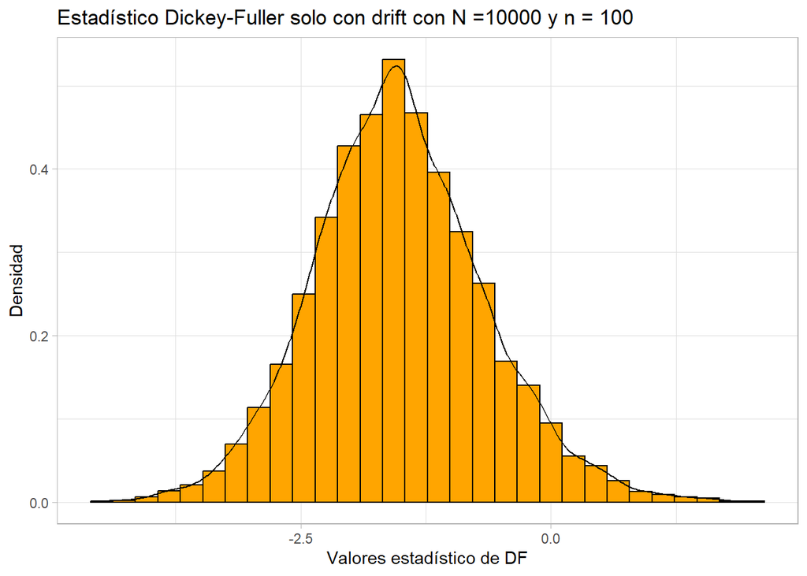

```r
hist_DF_drift = histogram_DF(df_drift,"Estadístico Dickey-Fuller solo con drift con N =10000 y n = 100","Valores estadístico de DF", "orange1");hist_DF_drift
```

Que obtiene una distribución para realizar prueba a una sola cola (izquierda).

Veamos los valores críticos con los que se realiza la prueba de hoipótesis.

```r
critical_drift = round(quantile(df_drift$DF_statistic, c(0.1, 0.05, 0.01)), 2); critical_drift
```

```
##   10%    5%    1%
## -2.56 -2.88 -3.47
```

## 1.4 Simulación sencilla

Esta regresión auxiliar no posee un término determinístico de tendencia ni una deriva. Nuevamente generemos esta simulación.

```r
df_none = simulacion_DF(n = n, N = N, tipo_prueba = "none", trend = trend, drift = drift)
```

Veamos la distribución del parámetro

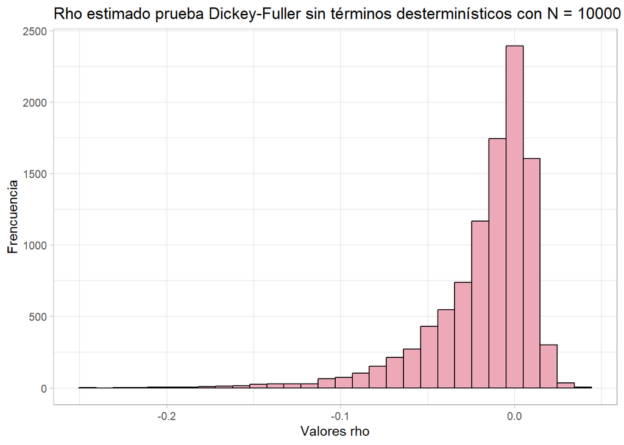

```r
histogram_rho_none = histogram_rho(df_none,
                                        "Rho estimado prueba Dickey-Fuller sin términos desterminísticos con N = 10000 y n = 100",
                                        "Valores rho", "pink2"); histogram_rho_none
```

Posteriormente la distribución del estadístico

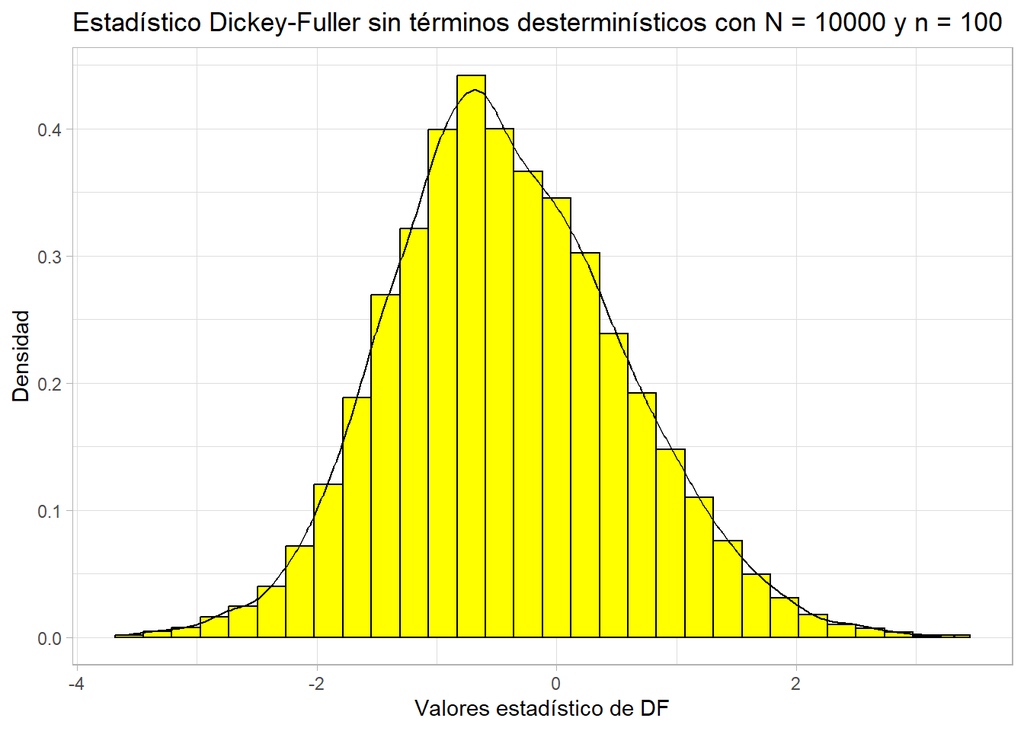

```r
hist_DF_none = histogram_DF(df_none,
                            "Estadístico Dickey-Fuller sin términos desterminísticos con N = 10000 y n = 100",
                            "Valores estadístico de DF", "yellow1"); hist_DF_none
```

Y finalmente, algunos valores críticos

```r
critical_none = round(quantile(df_none$DF_statistic, c(0.1, 0.05, 0.01)), 2); critical_none
```

```
##   10%    5%    1%
## -1.60 -1.91 -2.62
```

## 1.5 Contraste

Creamos un Data Frame en el cual sintetizamos los valores críticos de los tres tipos de prueba.

```r
critical_df = data.frame(sign_10 = double(), sign_5 = double(), sign_1 = double())
critical_df[1,] = critical_trend_drift
critical_df[2,] = critical_drift
critical_df[3,] = critical_none
names(critical_df)[1]="10%";names(critical_df)[2]="5%";names(critical_df)[3]="1%"
```

Visualicemos el Data Frame.

```r
critical_df
```

```
##     10%    5%    1%
## 1 -3.16 -3.46 -4.03
## 2 -2.56 -2.88 -3.47
## 3 -1.60 -1.91 -2.62
```

Para el siguiente contraste, usaremos una Data Frame donde se almacenen todas las series simuladas (incluyendo la Normal Estándar) para observar las diferencias presentes en la función de densidad de los estadísticos según cada especificación.

```r
df_todos = data.frame(DF_none = df_none$DF_statistic, DF_drift =df_drift$DF_statistic,DF_trend_drift = df_trend_drift$DF_statistic,Normal_estándar = rnorm(10000)) %>%
            pivot_longer(cols = 1:4, names_to = "Distribuciones", values_to="Valores_distribuciones")
```

Finalmente generamos el gráfico.

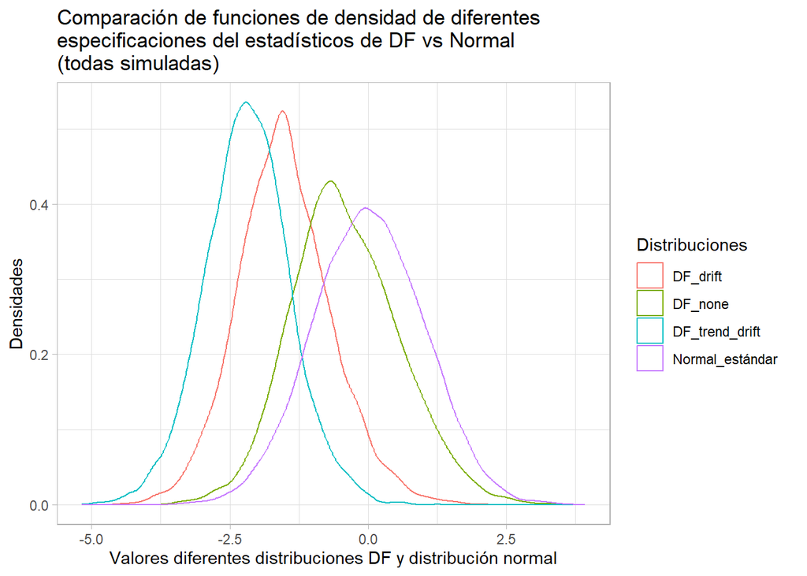

```r
x11()
density_comparacion = df_todos %>%
  ggplot(aes(x = Valores_distribuciones, color = Distribuciones)) +
  geom_density() +
  theme_light() +
  ggtitle("Comparación de funciones de densidad de diferentes\nespecificaciones del estadísticos de DF vs Normal\n(todas simuladas)") +
  ylab("Densidades") +
  xlab("Valores diferentes distribuciones DF y distribución normal"); density_comparacion
```

# 2. Uso práctico Dickey Fuller Aumentada (ADF) - Logaritmo del Consumo UK

## 2.1 Introducción

La estacionariedad de la serie es deseable para realizar pronóstico y manejar distintos enfoques para una serie de tiempo. Sin embargo, usualmente una serie debe ser diferenciada *n* veces para poder alcanzar un comportamiento estacional, por ende se dice que una serie tiene *n* orden de integración.

Para conocer el orden de integración de una serie se siguen los siguientes pasos:

1. Graficar la serie, determinando sus comportamientos en media y varianza
2. Mirar FAC y FACP, donde la primera debería tener un decaimiento geometrico.
3. Conducir la prueba secuencial de Dickey Fuller, con las especificaciones correctas (apartado I de este documento)
4. Si no hay estacionariedad, diferenciar la serie y repetir el procedimiento.

En la práctica, no basta con realizar un Test de Dickey Fuller, sino que se complementa con otras pruebas.

- Un ejemplo, es el uso de la prueba de kpss: cuya hipótesis nula es que la serie es estacionaria

Además, debemos asegurarnos que la serie no presenta cambio estructural pues la prueba Dickey Fuller supone NO cambio estructural.

- En el caso que presente, se debe implementar una prueba de raíz unitaria con cambio estructural como lo es el test de Zivot & Andrews. En urca el test de Zivot & Andrews es: ur.za

## 2.2 Carga y gráficos del Data Set

Los datos pertenecen al paquete urca.

```r
data(Raotbl3)
glimpse(Raotbl3)
```

```
## Rows: 99
## Columns: 6
## $ lc    <dbl> 10.4831, 10.4893, 10.5022, 10.5240, 10.5329, 10.5586, 10.5190, 1…
## $ li    <dbl> 10.5821, 10.5800, 10.5990, 10.6262, 10.6145, 10.6307, 10.6316, 1…
## $ lw    <dbl> 12.9481, 12.9895, 13.0115, 13.0411, 13.0357, 13.0518, 13.0839, 1…
## $ dd682 <dbl> NA, 0, 0, 0, 0, 0, 1, -1, 0, 0, 0, 0, 0, 0, 0, 0, 0, 0, 0, 0, 0,…
## $ dd792 <dbl> NA, 0, 0, 0, 0, 0, 0, 0, 0, 0, 0, 0, 0, 0, 0, 0, 0, 0, 0, 0, 0, …
## $ dd883 <dbl> NA, 0, 0, 0, 0, 0, 0, 0, 0, 0, 0, 0, 0, 0, 0, 0, 0, 0, 0, 0, 0, …
```

Una vez visualizada la base de datos, procedemos a realizar un gráfico.

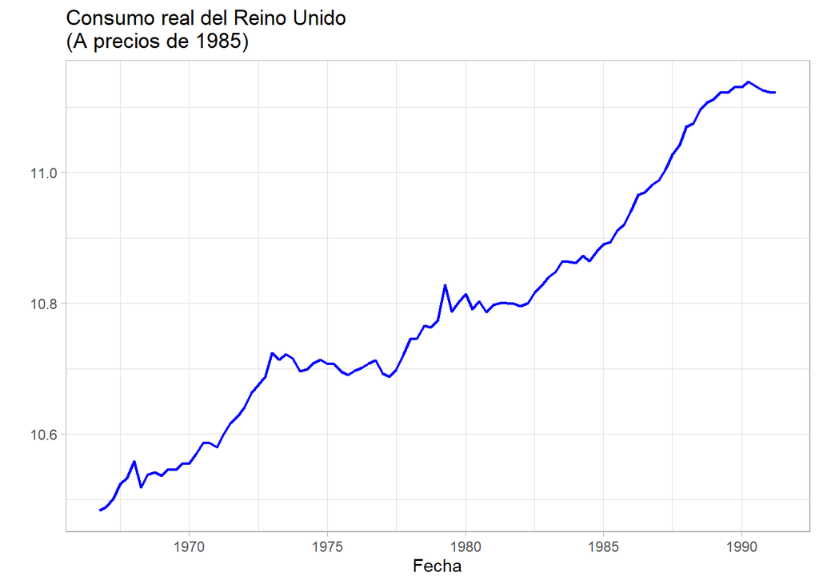

```r
# Como profesionales, primero convertimos a un objeto ts
lc = ts(Raotbl3$lc, start = c(1966, 4), end = c(1991, 2), frequency = 4)

# Graficamos
x11()
autoplot(lc, col="blue", main = "Consumo real del Reino Unido\n(A precios de 1985)",xlab = "Fecha", ylab="", lwd=0.8) + theme_light()
```

Ahora, graficamos los correlogramas para verificar un decaimiento geometrico a cero.

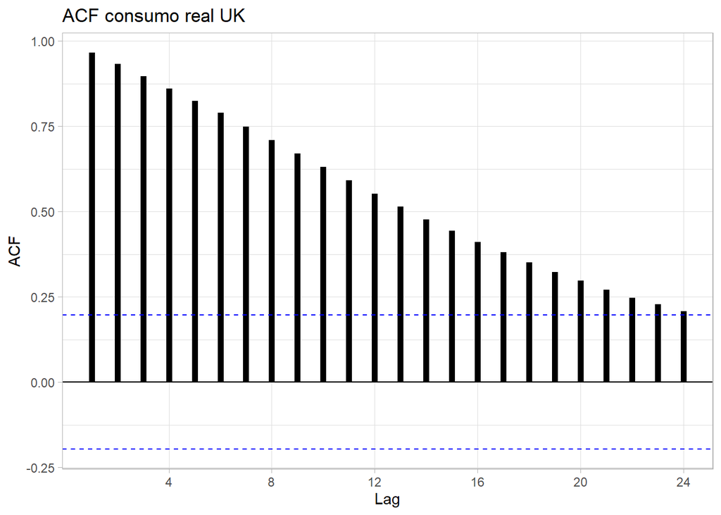

```r
lags = 24
x11()
ggAcf(lc,lag.max=lags,plot=T,lwd=2) + ggtitle("ACF consumo real UK") + theme_light()
```

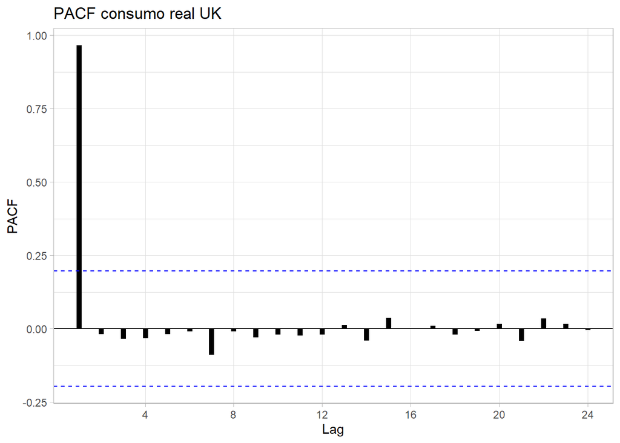

```r
ggPacf(lc,lag.max=lags,plot=T,lwd=2) + ggtitle("PACF consumo real UK")+ theme_light()
```

Ambas gráficas nos dan indicios de que no hay estacionariedad en la serie, por lo que es necesario realizar una prueba para estar seguros.

## 2.3 Aplicación de Prueba Dickey Fuller Aumentada

Esta prueba se realiza de manera secuencial iniciando por la prueba que contiene “trend” y continuando hasta la prueba con type = “none”.

Para la calibración del hiperparámetro lags existen dos métodos principales:

- 1. Método Automático: Se usa especificando *selectlags = “AIC”*. Como el nombre lo indica, usa el criterio de Akaike para determinar el número de rezagos.
- 2. Método Manual: Se especifica inicialmente *lags=1*, posteriormente se gráfican la fac de los residuales *plot(adf.xxx)* donde no **debe** haber correlación serial. Si hay rezagos del error correlacionados, se aumenta un lag en la especificación de la prueba.

Dado este contexto, realicemos la prueba a nuestra base de datos.

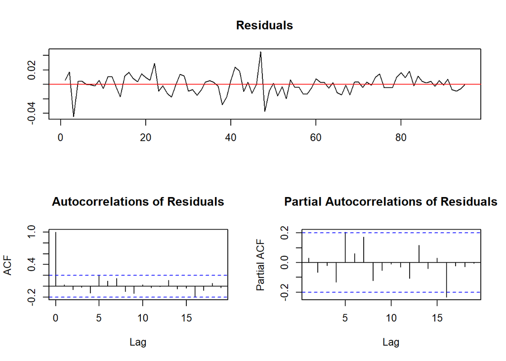

```
##
## ###############################################
## # Augmented Dickey-Fuller Test Unit Root Test #
## ###############################################
##
## Test regression trend
##
##
## Call:
## lm(formula = z.diff ~ z.lag.1 + 1 + tt + z.diff.lag)
##
## Residuals:
##       Min        1Q    Median        3Q       Max
## -0.044714 -0.006525  0.000129  0.006225  0.045353
##
## Coefficients:
##               Estimate Std. Error t value Pr(>|t|)
## (Intercept)  0.7976591  0.3547775   2.248   0.0270 *
## z.lag.1     -0.0758706  0.0338880  -2.239   0.0277 *
## tt           0.0004915  0.0002159   2.277   0.0252 *
## z.diff.lag1 -0.1063957  0.1006744  -1.057   0.2934
## z.diff.lag2  0.2011373  0.1012373   1.987   0.0500 .
## z.diff.lag3  0.2998586  0.1020548   2.938   0.0042 **
## ---
## Signif. codes:  0 '***' 0.001 '**' 0.01 '*' 0.05 '.' 0.1 ' ' 1
##
## Residual standard error: 0.01307 on 89 degrees of freedom
## Multiple R-squared:  0.1472, Adjusted R-squared:  0.09924
## F-statistic: 3.071 on 5 and 89 DF,  p-value: 0.01325
##
##
## Value of test-statistic is: -2.2389 3.7382 2.5972
##
## Critical values for test statistics:
##       1pct  5pct 10pct
## tau3 -4.04 -3.45 -3.15
## phi2  6.50  4.88  4.16
## phi3  8.73  6.49  5.47
```

```r
adf.trend = ur.df(lc, type = "trend", lags = 3); x11(); plot(adf.trend)
summary(adf.trend)
```

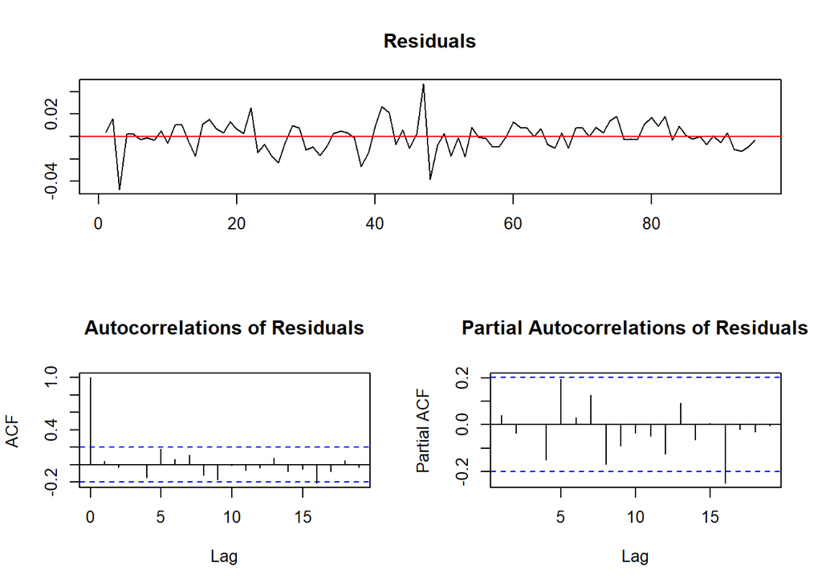

```
##
## ###############################################
## # Augmented Dickey-Fuller Test Unit Root Test #
## ###############################################
##
## Test regression drift
##
##
## Call:
## lm(formula = z.diff ~ z.lag.1 + 1 + z.diff.lag)
##
## Residuals:
##       Min        1Q    Median        3Q       Max
## -0.047547 -0.007071  0.000265  0.007731  0.046880
##
## Coefficients:
##               Estimate Std. Error t value Pr(>|t|)
## (Intercept)  0.0123237  0.0851358   0.145   0.8852
## z.lag.1     -0.0007356  0.0079043  -0.093   0.9261
## z.diff.lag1 -0.1433015  0.1016454  -1.410   0.1620
## z.diff.lag2  0.1615256  0.1020242   1.583   0.1169
## z.diff.lag3  0.2585280  0.1027364   2.516   0.0136 *
## ---
## Signif. codes:  0 '***' 0.001 '**' 0.01 '*' 0.05 '.' 0.1 ' ' 1
##
## Residual standard error: 0.01337 on 90 degrees of freedom
## Multiple R-squared:  0.09747,    Adjusted R-squared:  0.05735
## F-statistic:  2.43 on 4 and 90 DF,  p-value: 0.05335
##
##
## Value of test-statistic is: -0.0931 2.8806
##
## Critical values for test statistics:
##       1pct  5pct 10pct
## tau2 -3.51 -2.89 -2.58
## phi1  6.70  4.71  3.86
```

```r
adf.drift = ur.df(lc, type = "drift", lags = 3); x11(); plot(adf.drift)
summary(adf.drift)
```

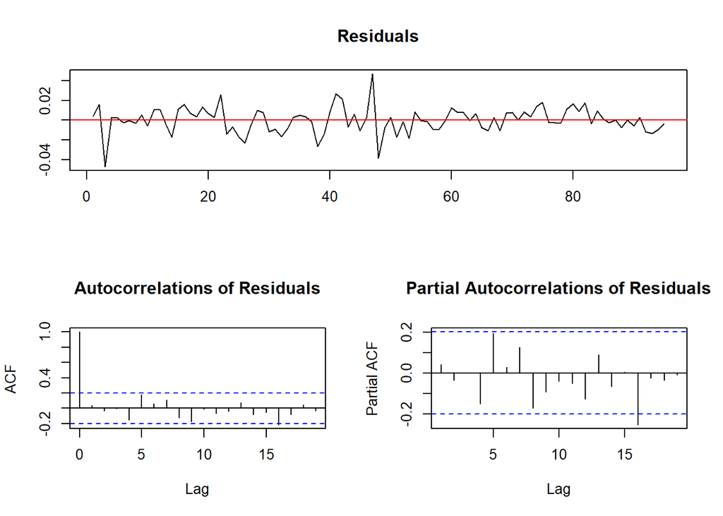

```
##
## ###############################################
## # Augmented Dickey-Fuller Test Unit Root Test #
## ###############################################
##
## Test regression none
##
##
## Call:
## lm(formula = z.diff ~ z.lag.1 - 1 + z.diff.lag)
##
## Residuals:
##       Min        1Q    Median        3Q       Max
## -0.047220 -0.007276  0.000229  0.007674  0.046921
##
## Coefficients:
##               Estimate Std. Error t value Pr(>|t|)
## z.lag.1      0.0004083  0.0001695   2.409   0.0180 *
## z.diff.lag1 -0.1444994  0.1007615  -1.434   0.1550
## z.diff.lag2  0.1599782  0.1009153   1.585   0.1164
## z.diff.lag3  0.2568572  0.1015353   2.530   0.0131 *
## ---
## Signif. codes:  0 '***' 0.001 '**' 0.01 '*' 0.05 '.' 0.1 ' ' 1
##
## Residual standard error: 0.0133 on 91 degrees of freedom
## Multiple R-squared:  0.2546, Adjusted R-squared:  0.2218
## F-statistic:  7.77 on 4 and 91 DF,  p-value: 1.967e-05
##
##
## Value of test-statistic is: 2.4089
##
## Critical values for test statistics:
##      1pct  5pct 10pct
## tau1 -2.6 -1.95 -1.61
```

```r
adf.none = ur.df(lc, type = "none", lags = 3); x11() ; plot(adf.none)
summary(adf.none)
```

El procedimiento secuencial indica que la serie no debería incluirsele ni drift ni trend,y que la serie no es estacionaria (Tau3).

Corroboramos con una prueba complementaria.

```r
summary(ur.kpss(lc))
```

```
##
## #######################
## # KPSS Unit Root Test #
## #######################
##
## Test is of type: mu with 3 lags.
##
## Value of test-statistic is: 2.4111
##
## Critical value for a significance level of:
##                 10pct  5pct 2.5pct  1pct
## critical values 0.347 0.463  0.574 0.739
```

Rechazo la hipótesis nula de estacionaridad, lo que indica que la serie no es estacionaria. Debemos diferenciar la serie.

## 2.4 Primera Diferencia

Aplicamos la diferencia y generamos el gráfico de la serie.

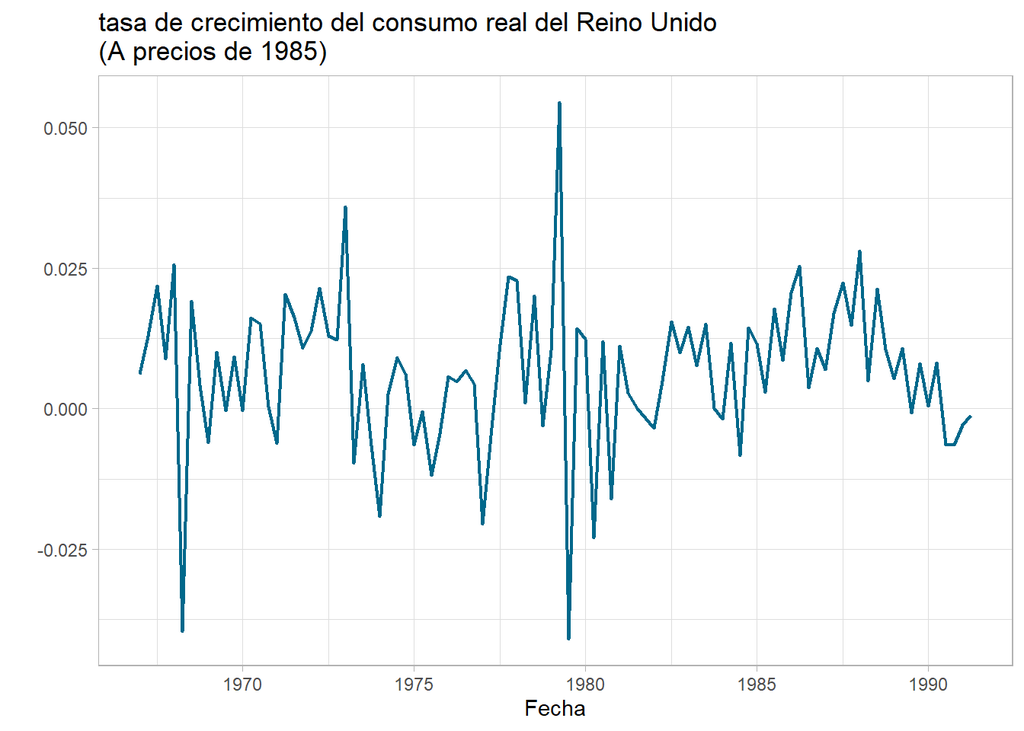

```r
diff.lc = diff(lc)
x11()
autoplot(diff.lc, col="deepskyblue4", main = "tasa de crecimiento del consumo real del Reino Unido\n(A precios de 1985)",xlab = "Fecha", ylab="", lwd=0.8) + theme_light()
```

Observemos los correlogramas.

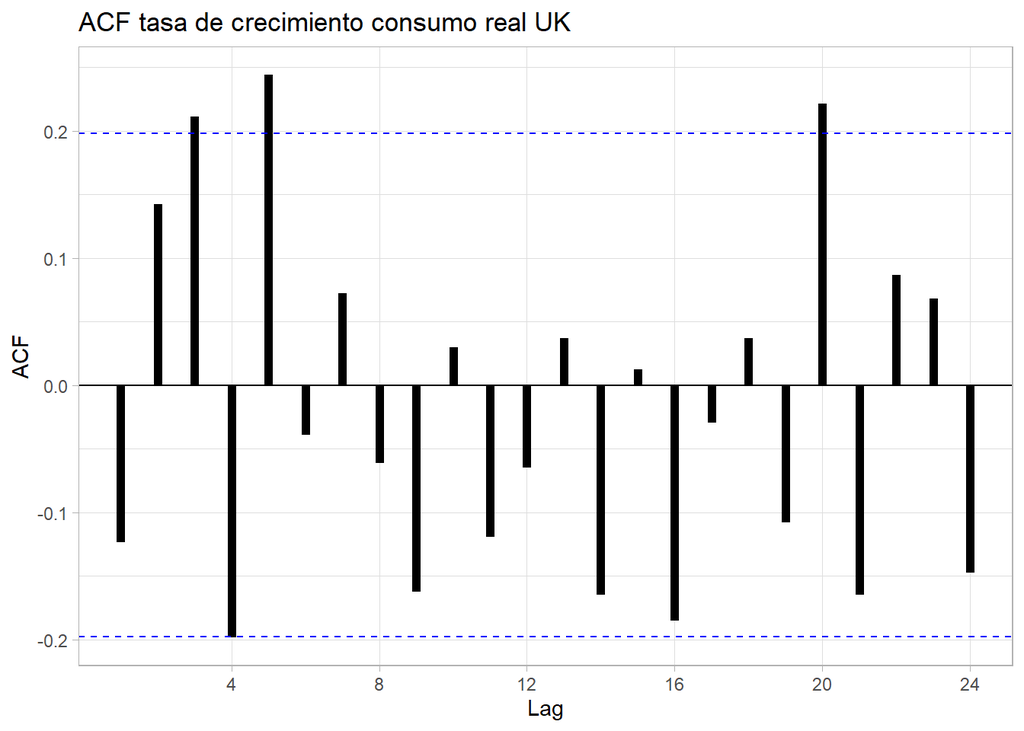

```r
lags = 24
x11()
ggAcf(diff.lc,lag.max=lags,plot=T,lwd=2) + ggtitle("ACF tasa de crecimiento consumo real UK") + theme_light()
```

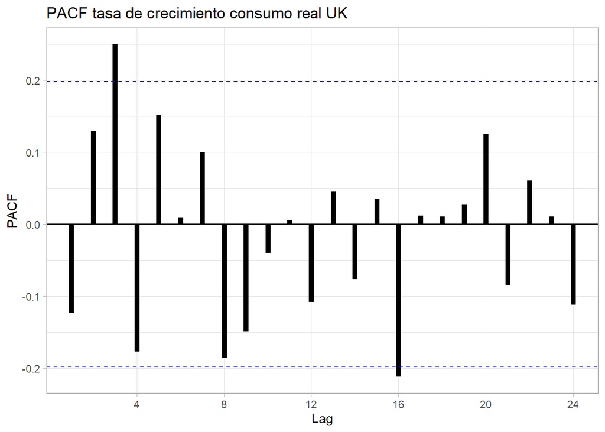

```r
ggPacf(diff.lc,lag.max=lags,plot=T,lwd=2) + ggtitle("PACF tasa de crecimiento consumo real UK")+ theme_light()
```

Ambas gráficas nos dan buenas pistas de la estacionariedad de la serie, sin embargo siempre se debe realizar una prueba formal.

Si la serie sin diferenciar no poseía deriva ni tendencia, la diferenciada tampoco.

```r
adf.diff.none = ur.df(diff.lc, type = "none", lags = 1);x11();plot(adf.diff.none)
```

[output not shown]

Debemos complementar con una prueba de KPSS.

```r
summary(ur.kpss(diff.lc))
```

```
##
## #######################
## # KPSS Unit Root Test #
## #######################
##
## Test is of type: mu with 3 lags.
##
## Value of test-statistic is: 0.0978
##
## Critical value for a significance level of:
##                 10pct  5pct 2.5pct  1pct
## critical values 0.347 0.463  0.574 0.739
```

No rechazo la hipótesis nula de estacionaridad, y por ende trabajo con la serie como si fuera estacionaria. Podemos confirmar que esta serie es I(1), es decir tiene un orden de integración de uno.

## 3. Aplicación de Prueba Dickey Fuller Aumentada - GDP real USA

## 3.1 Carga y gráficos del Data Set

Esta base de datos no es nativa, por lo que necesitamos importarla.

```r
gdp <- read_excel(file.choose())
glimpse(gdp)
```

```
## Rows: 264
## Columns: 7
## $ DATE      <dttm> 1947-01-01, 1947-04-01, 1947-07-01, 1947-10-01, 1948-01-01,…
## $ RGDP      <dbl> 1770.7, 1768.0, 1766.5, 1793.3, 1821.8, 1855.3, 1865.3, 1868…
## $ GDP       <dbl> 237.2, 240.4, 244.5, 254.3, 260.3, 267.3, 273.8, 275.1, 269.…
## $ Potential <dbl> NA, NA, NA, NA, NA, NA, NA, NA, 1867.0, 1885.3, 1903.9, 1922…
## $ RCons     <dbl> 1130.9, 1149.7, 1153.4, 1153.8, 1159.6, 1173.0, 1174.8, 1184…
## $ RGovt     <dbl> 407.250, 409.821, 413.577, 407.464, 415.526, 435.526, 444.00…
## $ Rinv      <dbl> 188.675, 173.485, 167.924, 202.712, 224.682, 239.489, 242.05…
```

Graficamos la serie.

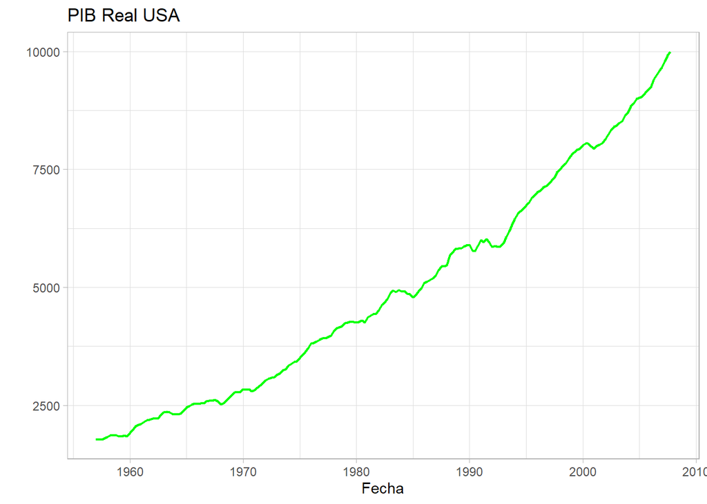

```r
real_gdp = ts(gdp$RGDP,start = c(1957,1), end = c(2007,4), frequency = 4)
x11()
autoplot(real_gdp, col="green", main = "PIB Real USA", xlab = "Fecha", ylab="", lwd=0.8) + theme_light()
```

Visualicemos los correlogramas.

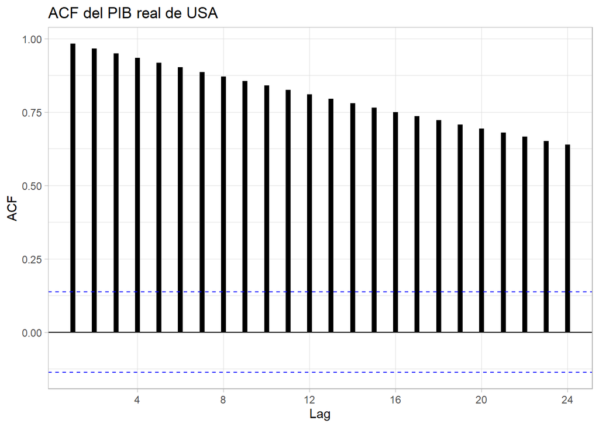

```r
lags = 24
x11()
ggAcf(real_gdp,lag.max=lags,plot=T,lwd=2) + ggtitle("ACF del PIB real de USA") + theme_light()
```

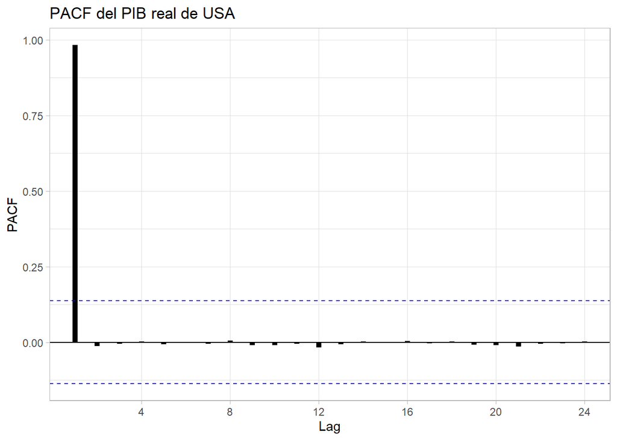

```r
ggPacf(real_gdp,lag.max=lags,plot=T,lwd=2) + ggtitle("PACF del PIB real de USA")+ theme_light()
```

No parece tener una estacionariedad aparente.

## 3.2 Aplicación de Prueba Dickey Fuller Aumentada

Realicemos igualmente la prueba secuencial.

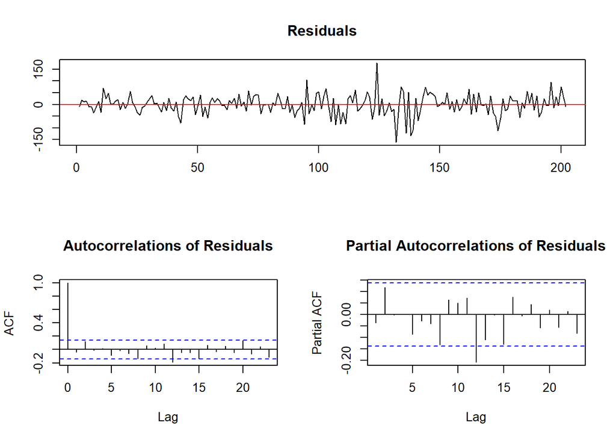

```
##
## ###############################################
## # Augmented Dickey-Fuller Test Unit Root Test #
## ###############################################
##
## Test regression trend
##
##
## Call:
## lm(formula = z.diff ~ z.lag.1 + 1 + tt + z.diff.lag)
##
## Residuals:
##      Min       1Q   Median       3Q      Max
## -160.820  -24.697   -0.061   25.778  176.603
##
## Coefficients:
##              Estimate Std. Error t value Pr(>|t|)
## (Intercept)  9.921700   9.802287   1.012    0.313
## z.lag.1     -0.001278   0.008160  -0.157    0.876
## tt           0.235922   0.318947   0.740    0.460
## z.diff.lag   0.320779   0.068120   4.709 4.67e-06 ***
## ---
## Signif. codes:  0 '***' 0.001 '**' 0.01 '*' 0.05 '.' 0.1 ' ' 1
##
## Residual standard error: 43.06 on 198 degrees of freedom
## Multiple R-squared:  0.2031, Adjusted R-squared:  0.1911
## F-statistic: 16.82 on 3 and 198 DF,  p-value: 8.937e-10
##
##
## Value of test-statistic is: -0.1566 16.8356 5.7395
##
## Critical values for test statistics:
##       1pct  5pct 10pct
## tau3 -3.99 -3.43 -3.13
## phi2  6.22  4.75  4.07
## phi3  8.43  6.49  5.47
```

```r
adf.trend = ur.df(real_gdp, type = "trend", lags = 1); x11(); plot(adf.trend)
summary(adf.trend)
```

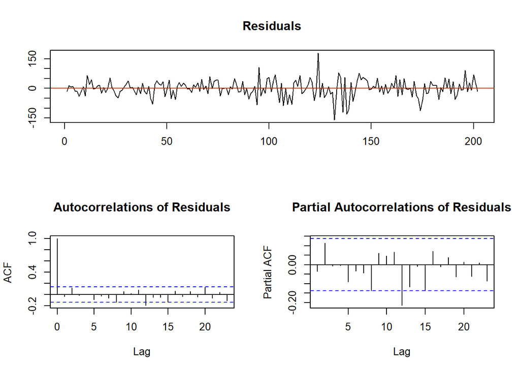

```
##
## ###############################################
## # Augmented Dickey-Fuller Test Unit Root Test #
## ###############################################
##
## Test regression drift
##
##
## Call:
## lm(formula = z.diff ~ z.lag.1 + 1 + z.diff.lag)
##
## Residuals:
##      Min       1Q   Median       3Q      Max
## -159.515  -24.888    0.257   26.880  178.628
##
## Coefficients:
##             Estimate Std. Error t value Pr(>|t|)
## (Intercept) 4.985334   7.171545   0.695  0.48777
## z.lag.1     0.004668   0.001410   3.310  0.00111 **
## z.diff.lag  0.316144   0.067754   4.666 5.63e-06 ***
## ---
## Signif. codes:  0 '***' 0.001 '**' 0.01 '*' 0.05 '.' 0.1 ' ' 1
##
## Residual standard error: 43.01 on 199 degrees of freedom
## Multiple R-squared:  0.2009, Adjusted R-squared:  0.1929
## F-statistic: 25.02 on 2 and 199 DF,  p-value: 2.028e-10
##
##
## Value of test-statistic is: 3.3101 25.0368
##
## Critical values for test statistics:
##       1pct  5pct 10pct
## tau2 -3.46 -2.88 -2.57
## phi1  6.52  4.63  3.81
```

```r
adf.drift = ur.df(real_gdp, type = "drift", lags = 1); x11(); plot(adf.drift)
summary(adf.drift)
```

El procedimiento secuencial indica que la serie no debería incluir trend lineal pero sí debería drift y que la serie no es estacionaria.

## 3.3 Primera diferencia

Aplicamos logaritmo, diferenciamos y graficamos la serie.

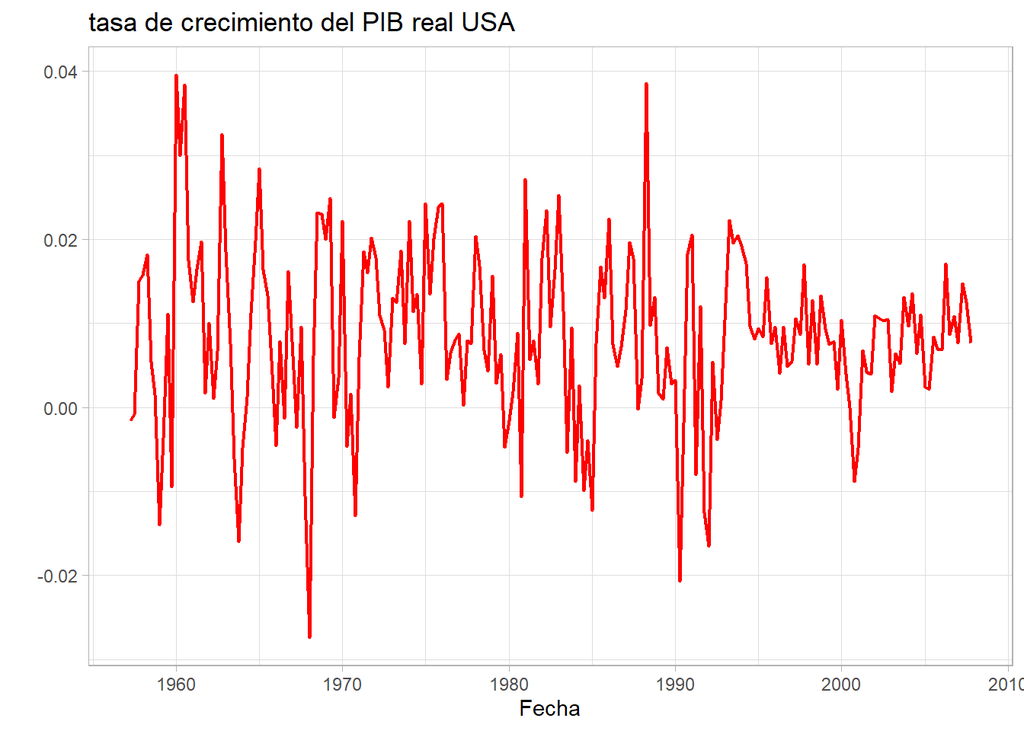

```r
dl.real_gdp = diff(log(real_gdp))
x11()
autoplot(dl.real_gdp, col="red", main = "tasa de crecimiento del PIB real USA",xlab = "Fecha", ylab="", lwd=0.8) + theme_light()
```

Observemos sus correlogramas.

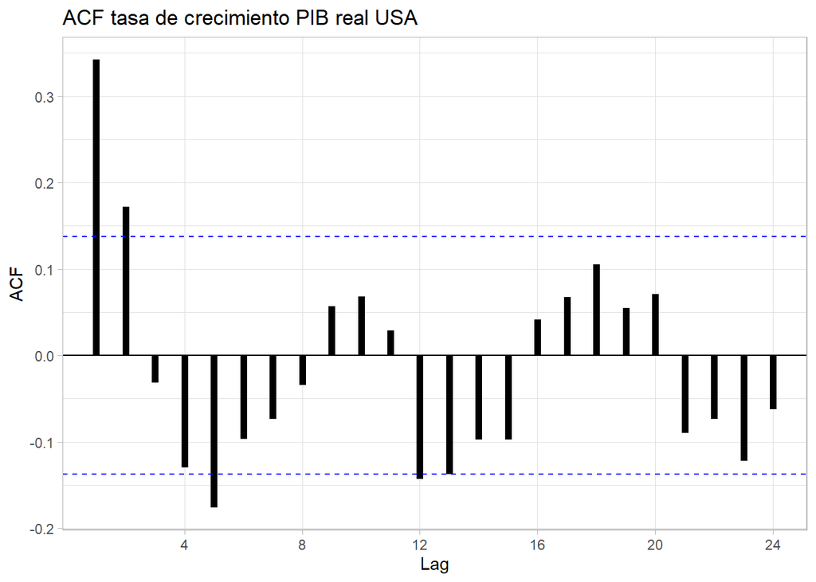

```r
lags = 24
x11()
ggAcf(dl.real_gdp,lag.max=lags,plot=T,lwd=2) + ggtitle("ACF tasa de crecimiento PIB real USA") + theme_light()
```

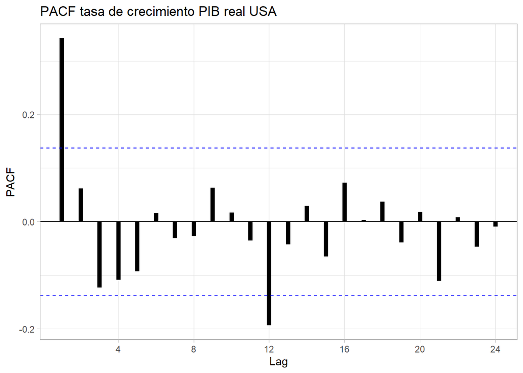

```r
ggPacf(dl.real_gdp,lag.max=lags,plot=T,lwd=2) + ggtitle("PACF tasa de crecimiento PIB real USA")+ theme_light()
```

En tanto posee una estacionariedad aparente, corroboremos con la prueba.

```r
adf.diff.drift = ur.df(dl.real_gdp,type="drift",lags=1);x11();plot(adf.diff.drift)
```

[output not shown]